# Pesticide

Sofian, Baptiste, Wilfred, Souleiman

2024-03-06

# PROBLEM STATEMENT

Prediction of the quantities of active substances purchased based on their attributes and climate data. Equation to estimate:
$$\ log(quantite\ substance_i)=\beta_0+\beta_1\
classification_i+\beta_2\ classification\ mention\ +\beta_3\ achat\
etranger_i + \beta_4\ log(dja_i)\ + \beta_5\ tmin moyen_i + \epsilon_i$$
$$\ log(quantite\
substance_i)=\alpha_0+\alpha_1\ log(dja_i)+\alpha_2\ tminmoyen_i\
+\alpha_3\ tminmoyen^2_i + \omicron_i$$

$$\ log(quantite\
substance_i)=\beta_0+\beta_1\ log(dja_i)+\beta_2\ tminmoyen2_i\
+\beta_3\ tminmoyen2^2_i + \epsilon_i$$
Intuitions:

-Parameters related to temperature are positive: the higher the minimum temperature, the less frost, so there is a need for more phytosanitary products. -Parameters related to toxicity are positive: the higher the ADI (Acceptable Daily Intake), the more substances can be ingested without harmful effects, so there is less reluctance to order more.

## DATA

We will import our data and build the database.

## Sources

Data import

The database contains 108,822 observations and 10 variables. It is a summary of agricultural product purchases in France in 2021.

## Building the Database

```
##   [1] "00"  "01"  "02"  "03"  "04"  "05"  "06"  "07"  "08"  "09"  "10"  "11"
##  [13] "12"  "13"  "14"  "15"  "16"  "17"  "18"  "19"  "21"  "22"  "23"  "24"
##  [25] "25"  "26"  "27"  "28"  "29"  "2A"  "2B"  "30"  "31"  "32"  "33"  "34"
##  [37] "35"  "36"  "37"  "38"  "39"  "40"  "41"  "42"  "43"  "44"  "45"  "46"
##  [49] "47"  "48"  "49"  "50"  "51"  "52"  "53"  "54"  "55"  "56"  "57"  "58"
##  [61] "59"  "60"  "61"  "62"  "63"  "64"  "65"  "66"  "67"  "68"  "69"  "70"
##  [73] "71"  "72"  "73"  "74"  "75"  "76"  "77"  "78"  "79"  "80"  "81"  "82"
##  [85] "83"  "84"  "85"  "86"  "87"  "88"  "89"  "90"  "91"  "92"  "93"  "94"
##  [97] "95"  "971" "972" "973" "974" "976"
```

|  |  | N | % |
| --- | --- | --- | --- |
| classification | Autre | 21140 | 19.4 |
|  | CMR | 19663 | 18.1 |
|  | Env A | 51635 | 47.4 |
|  | Env B | 8799 | 8.1 |
|  | Santé A | 7585 | 7.0 |
| classification_mention | Exclusion | 2175 | 2.0 |
|  | Substitution | 8501 | 7.8 |
|  | NA | 98146 | 90.2 |
| achat_etranger | Non | 106706 | 98.1 |
|  | Oui | 2116 | 1.9 |

[figure not shown]

[figure not shown]

[figure not shown]

We convert the variables “classification_mention” and “classification” into numeric variables

We will extract the average minimum temperatures from October to December 2021.

We then extract the average minimum temperatures for the whole year 2021.

The database now contains 105,231 observations and 11 variables. We have added the average minimum temperature between October and December by department.

Now we will add the Acceptable Daily Intake (ADI) for active substances in mg/kg.

Data can be found at this link:

https://www.google.com/url?sa=t&rct=j&q=&esrc=s&source=web&cd=&ved=2ahUKEwic3c2e9e6EAxXIcKQEHZq0D80QFnoECBwQAQ&url=https%3A%2F%2Ffood.ec.europa.eu%2Fsystem%2Ffiles%2F2017-02%2Fpesticides_ppp_app-proc_cfs_database-201501.xlsx&usg=AOvVaw3T9gdzKeazfxDwepsVvnk6&opi=89978449

We retrieve the ADI to have a toxicity index for humans.

```
## [1] 145
```

We have 145 substances in common between the two datasets.

```
## [1] 120
```

## Final number of observations

We now have 120 active substances.

Our final database contains 40,572 observations.

## Dependent variable and explanatory variables

We explain the quantities of substances purchased using the following explanatory variables:

-ADI: Acceptable Daily Intake refers to the amount of a substance that can be ingested daily by a consumer throughout life without harmful effects on health. It is typically expressed in milligrams of active substance per kilogram of body weight per day (mg/kg bw/day). -Average minimum temperature: Average minimum temperatures by department based on daily measurements in 2021. We will compare two models, one using temperatures for the whole year and the other for October to December 2021. The goal is to measure the impact of frost on quantities purchased. Frost has functions similar to pesticides, herbicides, and fungicides.

```
## [1] 96
```

```
## [1] 0.7417027
```

There is a strong correlation between the quantity of substance used and the useful agricultural area. SAU is thus a relevant variable for weighting the active agricultural substance.

We aim to explain the log of active substances purchased per hectare at the department level based on the average Acceptable Daily Intake and the average minimum temperature between October and December 2021.

```
## [1] 0.07203059
```

```
## [1] 0.07828306
```

```
## [1] 0.04106224
```

We tried to weight the quantities by the useful agricultural area per department, but the correlations remain very weak.

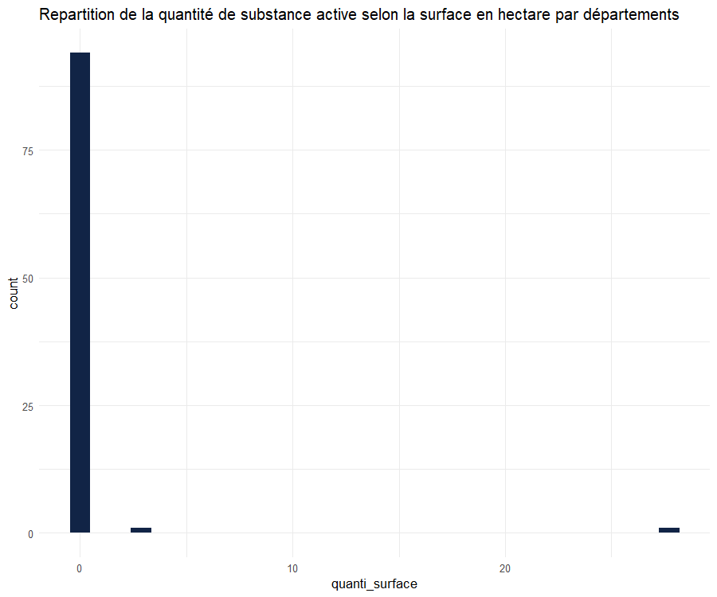

```
## [1] 8.057189
```

The quantity per surface area shows very little variation.

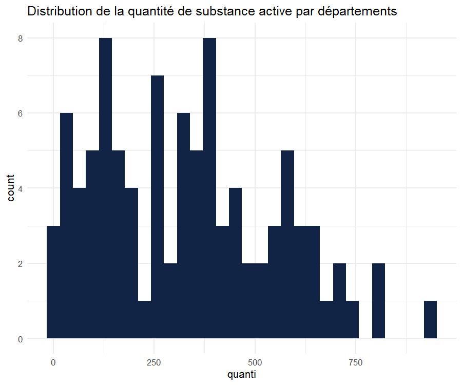

```
## [1] 48851.16
```

We will use the quantity variable.

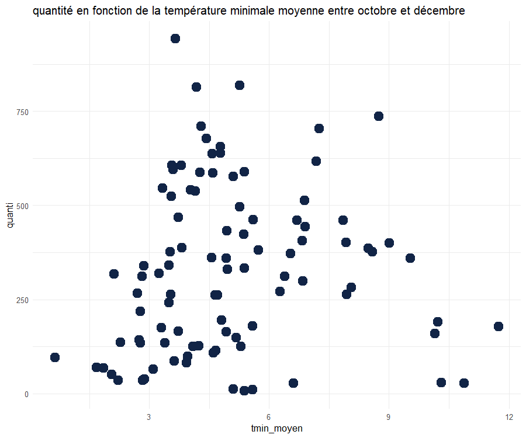

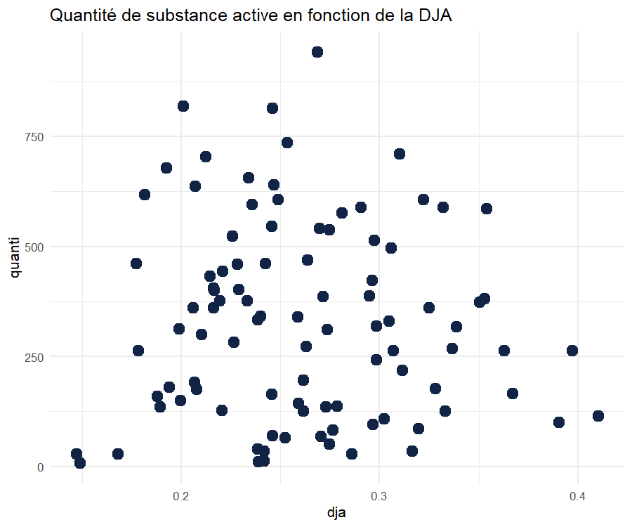

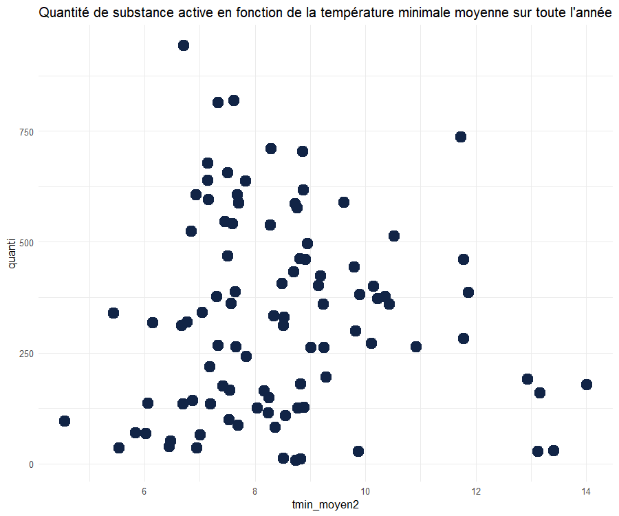

# DESCRIPTIVE STATISTICS

```
##  num_departement         sau             quanti             dja
##  Length:96          Min.   :     1   Min.   :  6.927   Min.   :0.1472
##  Class :character   1st Qu.:161315   1st Qu.:136.003   1st Qu.:0.2203
##  Mode  :character   Median :296647   Median :318.349   Median :0.2561
##                     Mean   :278602   Mean   :330.778   Mean   :0.2619
##                     3rd Qu.:387193   3rd Qu.:475.165   3rd Qu.:0.2985
##                     Max.   :557179   Max.   :942.337   Max.   :0.4103
##    tmin_moyen      tmin_moyen2     quanti_surface         t_min_sq
##  Min.   : 0.650   Min.   : 4.560   Min.   : 0.000147   Min.   :  0.4225
##  1st Qu.: 3.545   1st Qu.: 7.277   1st Qu.: 0.000838   1st Qu.: 12.5669
##  Median : 4.662   Median : 8.287   Median : 0.001180   Median : 21.7369
##  Mean   : 5.062   Mean   : 8.486   Mean   : 0.316048   Mean   : 30.4996
##  3rd Qu.: 6.299   3rd Qu.: 9.202   3rd Qu.: 0.001737   3rd Qu.: 39.6836
##  Max.   :11.745   Max.   :14.014   Max.   :27.728952   Max.   :137.9450
##    t_min_sq2
##  Min.   : 20.79
##  1st Qu.: 52.96
##  Median : 68.67
##  Mean   : 75.34
##  3rd Qu.: 84.69
##  Max.   :196.39
```

# ORDINARY LEAST SQUARES ESTIMATION

|  | modèle 1 | modèle 2 |
| --- | --- | --- |
| (Intercept) | 4.533*** | 1.443 |
|  | (0.811) | (1.947) |
| log(dja) | 0.673 | 0.456 |
|  | (0.494) | (0.490) |
| tmin_moyen | 0.666*** |  |
|  | (0.195) |  |
| t_min_sq | -0.050*** |  |
|  | (0.016) |  |
| tmin_moyen2 |  | 1.029** |
|  |  | (0.400) |
| t_min_sq2 |  | -0.054** |
|  |  | (0.021) |
| Num.Obs. | 96 | 96 |
| R2 | 0.124 | 0.078 |
| R2 Adj. | 0.095 | 0.048 |
| AIC | 1319.3 | 1324.2 |
| BIC | 1332.1 | 1337.0 |
| Log.Lik. | -131.774 | -134.211 |
| F | 4.323 | 2.591 |
| RMSE | 0.95 | 0.98 |

* p < 0.1, ** p < 0.05, *** p < 0.01

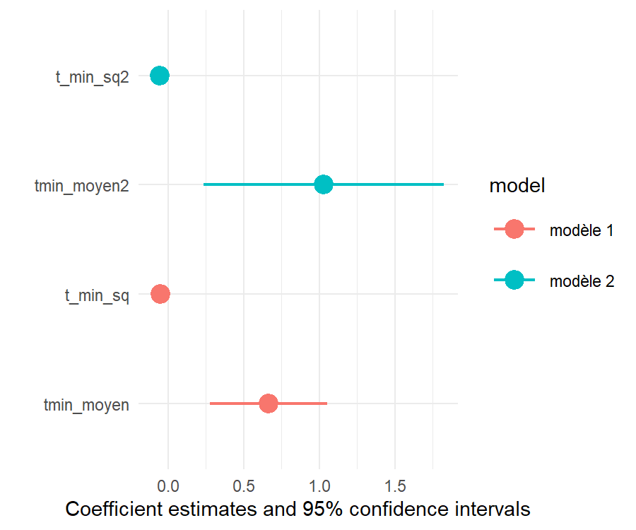

## Model Selection

```
##
##  studentized Breusch-Pagan test
##
## data:  model_4
## BP = 5.2034, df = 3, p-value = 0.1575
```

p-value > 0.05, we do not reject the hypothesis of homoscedasticity.

```
##
##  studentized Breusch-Pagan test
##
## data:  model_5
## BP = 5.3289, df = 3, p-value = 0.1492
```

p-value > 0.05, we do not reject the hypothesis of homoscedasticity.

We will go with model 1 since its R2 is higher than model 2.

When temperature increases, there is less frost, but after a certain point, frost no longer occurs, so the temperature’s impact diminishes.

## Hypothesis Testing

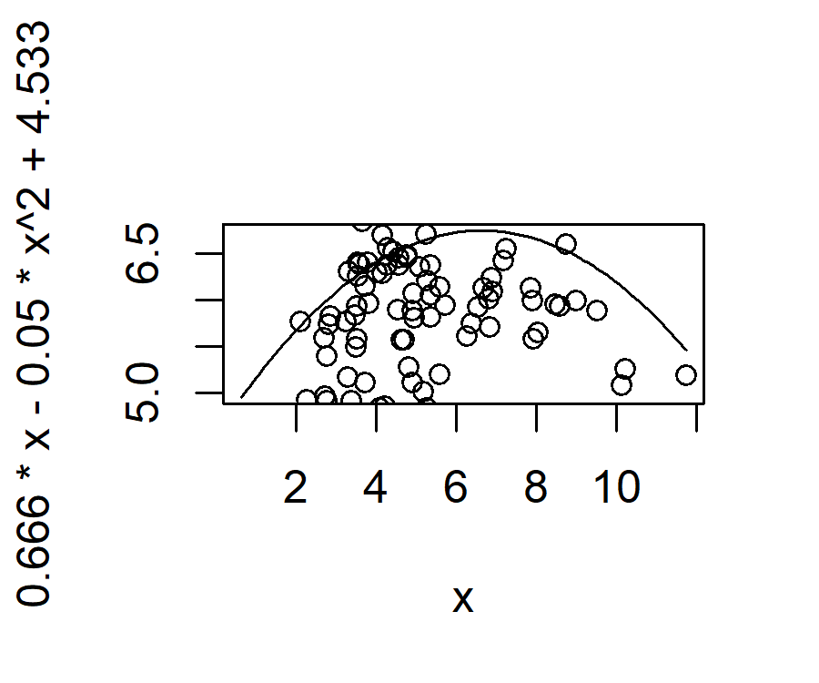

The ADI does not impact the quantities demanded.

Test H1:

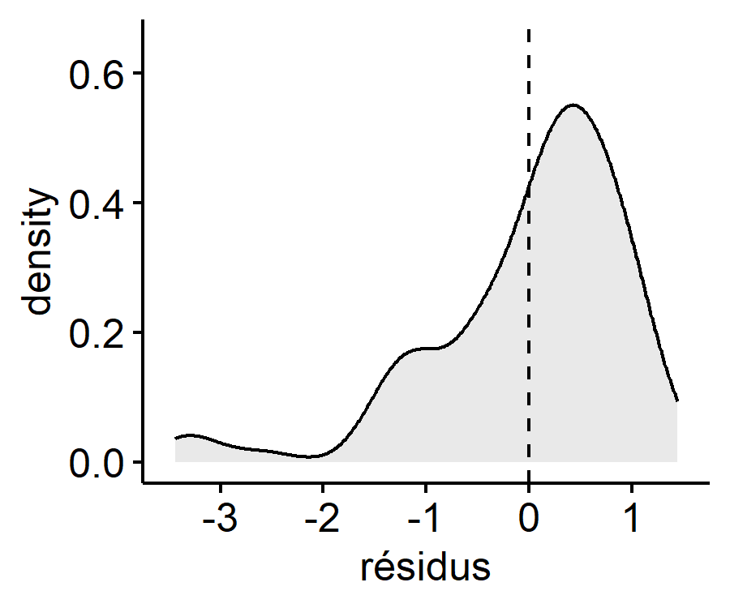

```
## # A tibble: 1 × 3
##   variable          statistic     p.value
##   <chr>                 <dbl>       <dbl>
## 1 model_4$residuals     0.875 0.000000174
```

P-value < 0.05, we do not reject the hypothesis of non-normality. The mean of errors is zero.

Test H2:

```
##
##  studentized Breusch-Pagan test
##
## data:  model_4
## BP = 5.2034, df = 3, p-value = 0.1575
```

P-value > 0.05, we do not reject the hypothesis of homoscedasticity. The errors are homoscedastic.

Test H3:

```
## [1] 7.487987e-17
```

```
## [1] -1.259936e-17
```

```
## [1] 8.374172e-17
```

The correlations between residuals and variables are close to zero.

Test H4:

During the process of approving a new phytopharmaceutical substance, scientists establish the No-Effect Dose (DSE), which is the dose below which no effects are observed in animals. The ADI is defined by dividing this DSE by at least 100. There may be measurement errors because the calculation does not differentiate effects, and dividing by 100 is not a scientific calculation. Also, we shift from a single dose to a daily dose. Therefore, the ADI as a toxicity standard can be questioned.

Additionally, we do not have the price of active substances, which is necessary for a demand function.

Test H5:

```
##                  data5.tmin_moyen log.data5.dja.
## data5.tmin_moyen        1.0000000     -0.3275352
## log.data5.dja.         -0.3275352      1.0000000
```